# L04 - Graphics, Glyphs, Frames, and Scales

Presenter- Olivia Beck  
Content Credit- Dr. Matthew Beckman

May 19, 2023

# Grammar of Graphics

- Wilkinson’s 2005 book *The Grammar of Graphics (2nd Ed.)* provides the principles and philosophy
  - the `ggplot2` R package implements this framework
  - **Goal**: flexible tools for building rich, intuitive graphics
- Data Visualization is critical to our goals for high quality Exploratory Data Analysis (EDA)
  1. **Examine the data source:** variable types, coding, missingness, summary statistics/plots, who/what/when/where/why/how data were collected
  2. **Discover features that influence may modeling decisions:** investigate potential outliers, consideration for recoding variables (e.g., numeric data that’s functionally dichotomous), evaluate correlation structure (e.g., autocorrelation, hierarchy, spatial/temporal proximity)
  3. **Address research questions:** build intuition and note preliminary observations/conclusions related to each research question. Also, note observations that prompt you to refine your research questions or add new questions to investigate

[figure not shown]

# Glyphs and Data

In archaeology, a GLYPH is a symbol or “mark” used to impart meaning:

Mayan GLYPH

[figure not shown]

# Data Glyph

### A data glyph is also a “mark” on a graph, e.g.

The features of a data glyph encodes the value of variables.

See: *https://ggplot2.tidyverse.org/reference/*

# Some Graphics Components

#### **glyph**

- The basic graphical unit often corresponding to one case.
- Other terms used include *mark* and *symbol*.

#### **aesthetic**

- a visual property of a glyph such as position, size, shape, color, etc.
- may be **mapped** based on data values: `sex -> color`
- may be **set** to particular non-data related values: `color is black`

#### **scale**

- A mapping that translates data values into aesthetics. For example,
- A scatter plot of health risks may identify cigarette smoking:
  - blue represents “No”
  - red represents “Yes”
- A printed map of campus uses a scaled representation of distance
  - a centimeter on the printed map represents 100 meters of distance on campus

#### **frame**

- The position scale describing how data are mapped to the coordinate system in use
- Quite often, the frame defines the x-axis and y-axis of a 2-dimensional cartesian plane

#### **guide**

- An indication for the human viewer of the scale. This allows the viewer to translate aesthetics back into data values.
- For example,
  - a legend makes explicit the meaning of Red & Blue points on the chart
  - a 1 cm length printed on a map to inform the reader that it corresponds to 100 meters on campus

Can you determine all the components on the following graph?

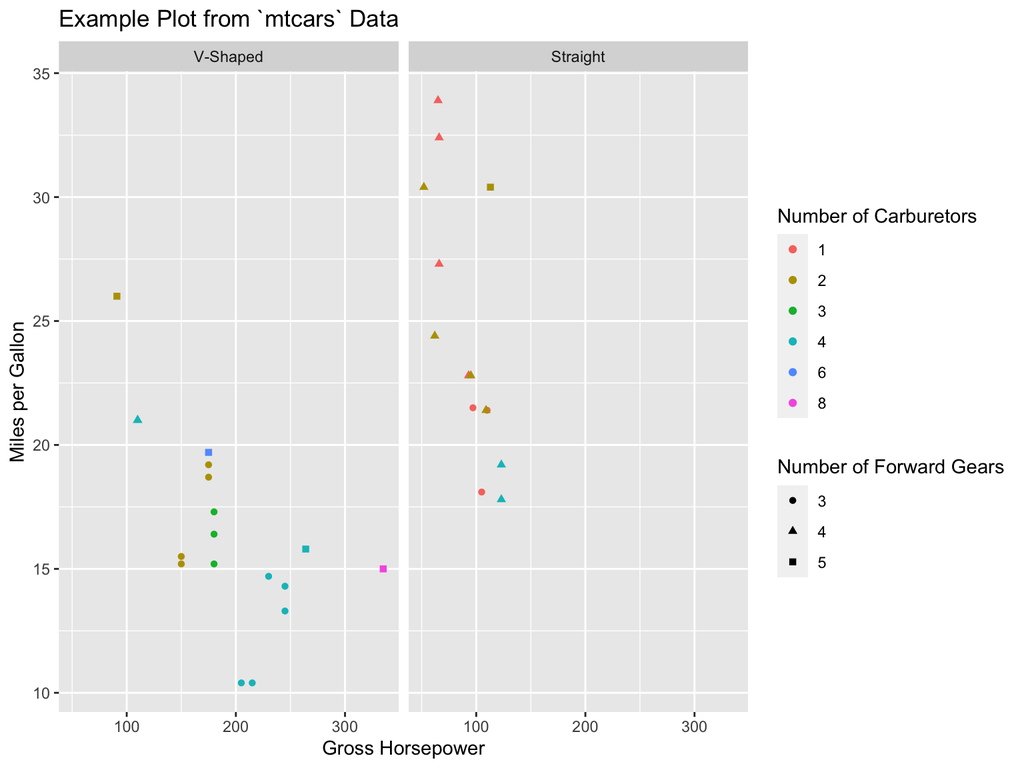

```r
#?mtcars
data("mtcars")

mtcars %>%
  ggplot() +
  geom_point(aes(x = hp,
                 y = mpg,
                 color = as.factor(carb),
                 shape = as.factor(gear))) +
  facet_grid(~vs,
             labeller = labeller(vs = c("0" = "V-Shaped",
                                        "1" = "Straight"))) +
  ggtitle("Example Plot from `mtcars` Data") +
  xlab("Gross Horsepower") +
  ylab("Miles per Gallon") +
  scale_shape_discrete(name = "Number of Forward Gears") +
  scale_color_discrete(name = "Number of Carburetors")
```

# An Example

```r
#install.packages("devtools")
#devtools::install_github("mdbeckman/dcData")
library(dcData)
library(tidyverse)
dat <- NCHS %>%
  dplyr::select(sex, age, smoker, bpd, weight) %>%
  na.omit()

head(dat)
```

```
##      sex age smoker bpd weight
## 2   male  77     no  56   75.4
## 3 female  10     no  63   32.9
## 5   male  49    yes  83   92.5
## 6 female  19     no  70   59.2
## 7 female  59     no  81   78.0
## 8   male  13     no  52   40.7
```

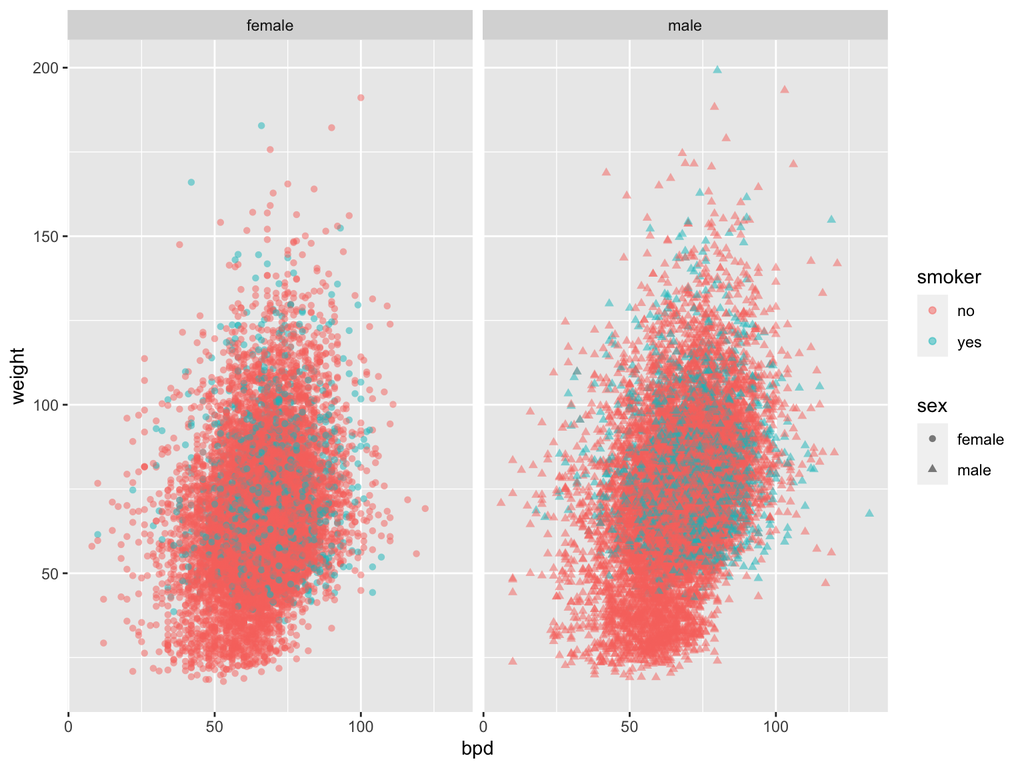

```r
dat %>%
  ggplot(aes(x = bpd, y = weight, color = smoker, shape = sex)) +
  geom_point(alpha = 0.5) +
  facet_wrap( ~ sex)
```

# Scales

#### The relationship between the variable value and the value of the aesthetic the variable is mapped to.

- Diastolic Blood Pressure (bpd) has units of mmHg (millimeters of mercury)
- Weight is measured in kg

The conversion from Smoker to color is a *scale*.

# Guides

#### Guide: an indication to a human viewer of what the scale is.

- Axis ticks and numbers

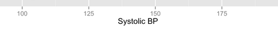

- Legends

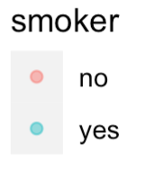

- Labels on faceted graphics

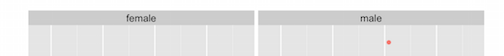

# Facets

- (x,y) is determined by `Time` and `weight`
- creates a separate frame for each `Diet`
- uses same x and y on each facet (scales can be the same or different)

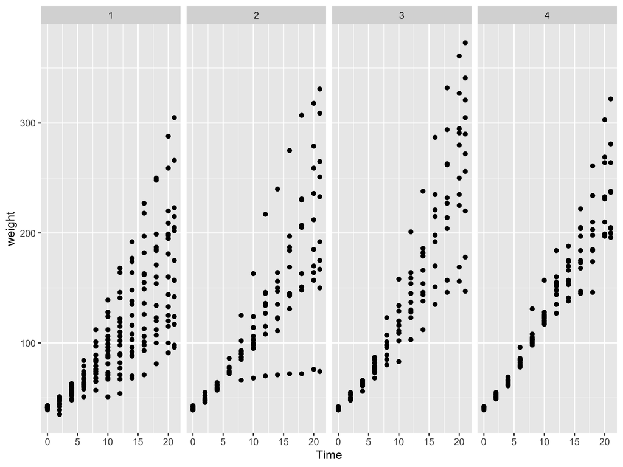

```r
#?ChickWeight
data("ChickWeight")

ChickWeight %>%
  ggplot(aes(x = Time, y = weight)) +
  geom_point()+
  facet_grid( ~ Diet)
```

# Designing Graphics

Graphics are designed by the human expert (you!) in order to reveal information that’s present in the data.

#### Design choices

- What kind of glyph, e.g. scatter, density, bar, … many others
- What variables constitute the frame. And some details:
  - axis limits
  - logarithmic axes, etc.
- What variables should be mapped to other aesthetics of the glyph.
- Whether to facet and with what variable.

More details, …, e.g. setting of aesthetics to constants

# Good and Bad Graphics

Remember …

> Graphics are designed by the human expert (you!) in order to reveal information that’s present in the data.
- choices depend on what information you want to convey.
- practice reading graphics and critique which ways of arranging thing are better or worse.
- A basic principle is that a graphic is about *comparison*. Good graphics:
  - make it easy for people to perceive things that are similar and things that are different.
  - put the things to be compared in proximity to one another (e.g., “side-by-side”)

# Perception and Comparison

In roughly descending order of human ability to compare nearby objects:

1. Position
2. Length
3. Area
4. Angle
5. Shape (but only a very few different shapes)
6. Color

Color is the most difficult…

- color gradients — we’re better at
- discrete colors — must be carefully selected.
- lots of people are color blind ([1 in 12 men; 1 in 200 women](http://www.colourblindawareness.org/))

For more, see:

Cleveland W. (1985). *The elements of graphing data*. Bell Telephone Laboratories: Murray Hill, NJ.

# Glyph-Ready Data

Glyph-ready data has this form:

- There is one row for each glyph to be drawn.
- The variables in that row are mapped to aesthetics of the glyph (including position)
- Glyph-ready data is often, but not not always, tidy data. But `tidyverse` makes it is very easy to go between the two!

**Glyph-ready data**

```
##   Sepal.Length Sepal.Width Petal.Length Petal.Width Species
## 1          5.1         3.5          1.4         0.2  setosa
## 2          4.9         3.0          1.4         0.2  setosa
## 3          4.7         3.2          1.3         0.2  setosa
## 4          4.6         3.1          1.5         0.2  setosa
## 5          5.0         3.6          1.4         0.2  setosa
## 6          5.4         3.9          1.7         0.4  setosa
```

**Mapping of data to aesthetics**

```
Sepal.Length -> x position
Petal.Length -> y position
Species -> color
```

Scales determine details of translation from

`variable -> aesthetic`

# Layers – building up complex plots

Each layer may have its own data, glyphs, aesthetic mapping, etc.

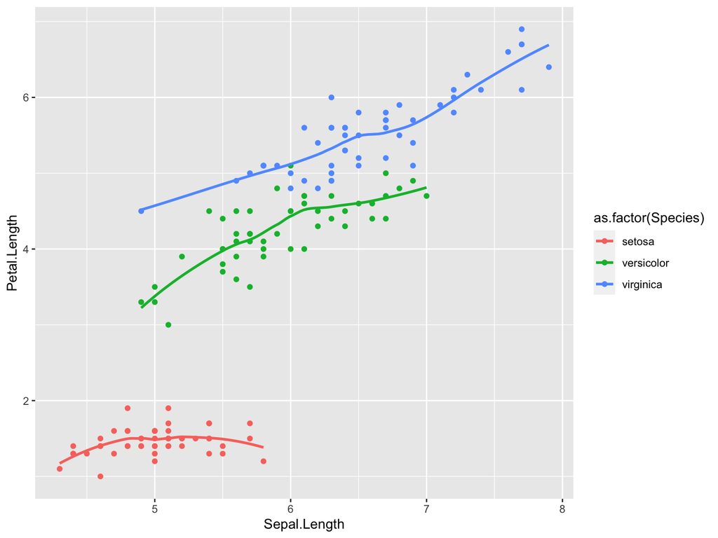

```r
ggplot(data = iris , aes(x = Sepal.Length, y = Petal.Length, colour = as.factor(Species))) +
  geom_point() +
  geom_smooth(se = FALSE)
```

- one layer has points
- another layer has the curves

# Stats: Data Transformations

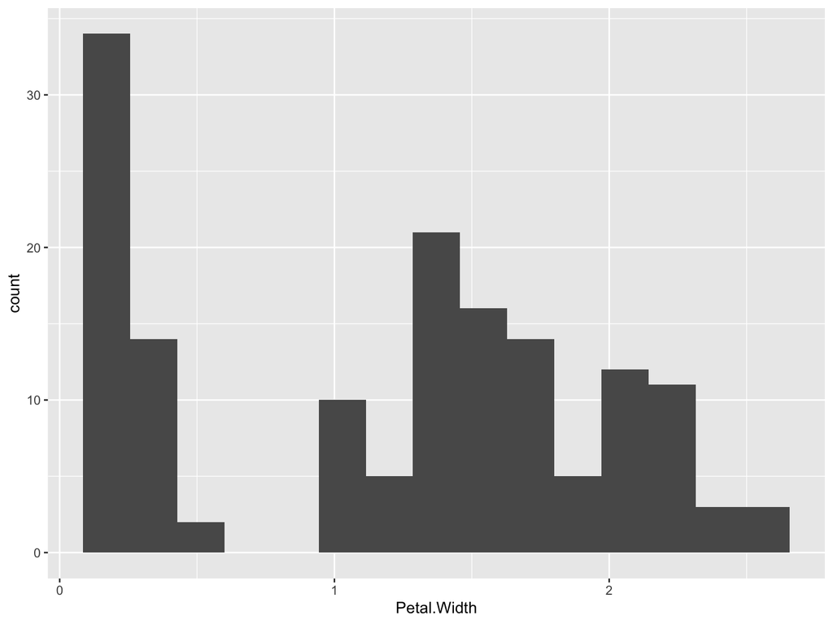

```r
ggplot(data = iris , aes(x = Petal.Width)) +
  geom_histogram(bins = 15)
```

- What are the glyphs, aesthetics, guides, etc. for this plot?
- How is the data for this plot related to the “raw” data?

# Path to success

1. **Eye-training**
   - recognize and describe glyphs, aesthetics, scales, etc.
   - identify data required for a plot
2. **Data wrangling**
   - get data into glyph-ready format (`dplyr`, `tidyr`, `tidyverse`)
   - (we’ll start doing this next week!)
3. **Graphics construction**
   - Newbies: match variables to aesthetics **interactively**:
     - `esquisse` package using `esquisser( )`
     - `mosaic` package using `mplot( )`
     - BOTH generate `ggplot2` syntax
   - Pros: learn to write `ggplot2` code directly

# The Big Mac Index

https://github.com/rfordatascience/tidytuesday/tree/master/data/2020/2020-12-22

```r
# These data are available from the `tidytuesdayR` package
# Install package from CRAN via: install.packages("tidytuesdayR")

library(tidytuesdayR)

TidyTuesData <- tidytuesdayR::tt_load(2020, week = 52)
BigMac <- TidyTuesData[["big-mac"]]
```

# Big Mac Price vs GPD per Capita?

Let’s use the `esquisse` package to explore the data!

In the console:

`esquisser(BigMac)`

Or you can use the `mplot(BigMac)` function from the `mosaic` package.

```r
library(esquisse)

# use `esquisser( )` to draft a plot and then generate R code to put here!
```

### Here’s an example:

[figure not shown]

```r
ggplot(BigMac) +
 aes(x = gdp_dollar, y = dollar_price) +
 geom_point(size = 1L, colour = "#0c4c8a") +
 labs(title = "Big Mac Price Around the World vs GDP per Capita") +
 theme_minimal()
```

- Using the graph, what can you say about the following?
  - Frame
  - Glyph
  - Aesthetic
  - Scale
  - Guide
  - Facet

# Value of Big Mac around the world

```
## Mapping API still under development and may change in future releases.
```

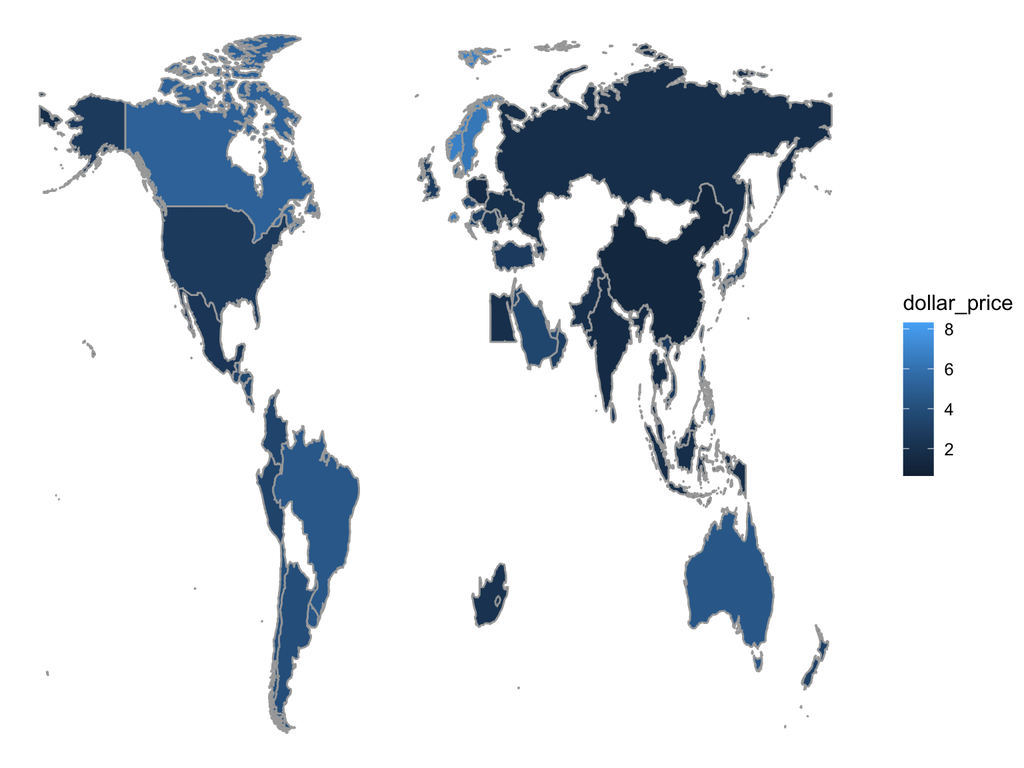

```r
# using `mWorldMap( )` from `mosaic` package
library(mosaic)

# `key` argument takes the ID variable; `fill` takes the measured variable
mWorldMap(BigMac, key = "iso_a3", fill = "dollar_price")
```

- Using the graph, what can you say about the following?
  - Frame
  - Glyph
  - Aesthetic
  - Scale
  - Guide
  - Facet